# Task 5 part 1

Perform ‘Exploratory Data Analysis’ on dataset ‘Indian Premier League’

● As a sports analysts, find out the most successful teams, players and factors contributing win or loss of a team.

● Suggest teams or players a company should endorse for its products.

● You can choose any of the tool of your choice (Python/R/Tableau/PowerBI/Excel/SAP/SAS)

```python
import pandas as pd
import numpy as np
import seaborn as sn
import plotly.express as px
import plotly.graph_objects as go
import plotly.offline as py
from plotly.subplots import make_subplots
from plotly import tools
import matplotlib.pyplot as plt
%matplotlib inline
```

```python
deliveries = pd.read_csv('deliveries.csv')
matches = pd.read_csv('matches.csv')
```

```python
pd.set_option('display.max_columns',None)
```

```python
deliveries.head(3)
```

|  | match_id | inning | batting_team | bowling_team | over | ball | batsman | non_striker | bowler | is_super_over | wide_runs | bye_runs | legbye_runs | noball_runs | penalty_runs | batsman_runs | extra_runs | total_runs | player_dismissed | dismissal_kind | fielder |
| --- | --- | --- | --- | --- | --- | --- | --- | --- | --- | --- | --- | --- | --- | --- | --- | --- | --- | --- | --- | --- | --- |
| 0 | 1 | 1 | Sunrisers Hyderabad | Royal Challengers Bangalore | 1 | 1 | DA Warner | S Dhawan | TS Mills | 0 | 0 | 0 | 0 | 0 | 0 | 0 | 0 | 0 | NaN | NaN | NaN |
| 1 | 1 | 1 | Sunrisers Hyderabad | Royal Challengers Bangalore | 1 | 2 | DA Warner | S Dhawan | TS Mills | 0 | 0 | 0 | 0 | 0 | 0 | 0 | 0 | 0 | NaN | NaN | NaN |
| 2 | 1 | 1 | Sunrisers Hyderabad | Royal Challengers Bangalore | 1 | 3 | DA Warner | S Dhawan | TS Mills | 0 | 0 | 0 | 0 | 0 | 0 | 4 | 0 | 4 | NaN | NaN | NaN |

```python
deliveries.shape,matches.shape
```

```
((179078, 21), (756, 18))
```

```python
matches.head(3)
```

|  | id | season | city | date | team1 | team2 | toss_winner | toss_decision | result | dl_applied | winner | win_by_runs | win_by_wickets | player_of_match | venue | umpire1 | umpire2 | umpire3 |
| --- | --- | --- | --- | --- | --- | --- | --- | --- | --- | --- | --- | --- | --- | --- | --- | --- | --- | --- |
| 0 | 1 | 2017 | Hyderabad | 2017-04-05 | Sunrisers Hyderabad | Royal Challengers Bangalore | Royal Challengers Bangalore | field | normal | 0 | Sunrisers Hyderabad | 35 | 0 | Yuvraj Singh | Rajiv Gandhi International Stadium, Uppal | AY Dandekar | NJ Llong | NaN |
| 1 | 2 | 2017 | Pune | 2017-04-06 | Mumbai Indians | Rising Pune Supergiant | Rising Pune Supergiant | field | normal | 0 | Rising Pune Supergiant | 0 | 7 | SPD Smith | Maharashtra Cricket Association Stadium | A Nand Kishore | S Ravi | NaN |
| 2 | 3 | 2017 | Rajkot | 2017-04-07 | Gujarat Lions | Kolkata Knight Riders | Kolkata Knight Riders | field | normal | 0 | Kolkata Knight Riders | 0 | 10 | CA Lynn | Saurashtra Cricket Association Stadium | Nitin Menon | CK Nandan | NaN |

```python
matches.columns
```

```
Index(['id', 'season', 'city', 'date', 'team1', 'team2', 'toss_winner',
       'toss_decision', 'result', 'dl_applied', 'winner', 'win_by_runs',
       'win_by_wickets', 'player_of_match', 'venue', 'umpire1', 'umpire2',
       'umpire3'],
      dtype='object')
```

```python
temp_match = matches[['season','team1', 'team2','toss_winner','toss_decision','winner', 'win_by_runs',
       'win_by_wickets', 'player_of_match', 'venue']]
temp_match.head()
```

|  | season | team1 | team2 | toss_winner | toss_decision | winner | win_by_runs | win_by_wickets | player_of_match | venue |
| --- | --- | --- | --- | --- | --- | --- | --- | --- | --- | --- |
| 0 | 2017 | Sunrisers Hyderabad | Royal Challengers Bangalore | Royal Challengers Bangalore | field | Sunrisers Hyderabad | 35 | 0 | Yuvraj Singh | Rajiv Gandhi International Stadium, Uppal |
| 1 | 2017 | Mumbai Indians | Rising Pune Supergiant | Rising Pune Supergiant | field | Rising Pune Supergiant | 0 | 7 | SPD Smith | Maharashtra Cricket Association Stadium |
| 2 | 2017 | Gujarat Lions | Kolkata Knight Riders | Kolkata Knight Riders | field | Kolkata Knight Riders | 0 | 10 | CA Lynn | Saurashtra Cricket Association Stadium |
| 3 | 2017 | Rising Pune Supergiant | Kings XI Punjab | Kings XI Punjab | field | Kings XI Punjab | 0 | 6 | GJ Maxwell | Holkar Cricket Stadium |
| 4 | 2017 | Royal Challengers Bangalore | Delhi Daredevils | Royal Challengers Bangalore | bat | Royal Challengers Bangalore | 15 | 0 | KM Jadhav | M Chinnaswamy Stadium |

```python
temp_match['season'].unique()
```

```
array([2017, 2008, 2009, 2010, 2011, 2012, 2013, 2014, 2015, 2016, 2018,
       2019], dtype=int64)
```

```python
temp_match = temp_match.sort_values('season',ascending=True).reset_index()
temp_match = temp_match.drop(['index'],axis = 1)
temp_match.head()
```

|  | season | team1 | team2 | toss_winner | toss_decision | winner | win_by_runs | win_by_wickets | player_of_match | venue |
| --- | --- | --- | --- | --- | --- | --- | --- | --- | --- | --- |
| 0 | 2008 | Chennai Super Kings | Rajasthan Royals | Rajasthan Royals | field | Rajasthan Royals | 0 | 3 | YK Pathan | Dr DY Patil Sports Academy |
| 1 | 2008 | Chennai Super Kings | Rajasthan Royals | Chennai Super Kings | bat | Rajasthan Royals | 0 | 8 | Sohail Tanvir | Sawai Mansingh Stadium |
| 2 | 2008 | Mumbai Indians | Delhi Daredevils | Delhi Daredevils | field | Mumbai Indians | 29 | 0 | SM Pollock | Dr DY Patil Sports Academy |
| 3 | 2008 | Kings XI Punjab | Kolkata Knight Riders | Kings XI Punjab | bat | Kings XI Punjab | 9 | 0 | IK Pathan | Punjab Cricket Association Stadium, Mohali |
| 4 | 2008 | Deccan Chargers | Royal Challengers Bangalore | Deccan Chargers | bat | Royal Challengers Bangalore | 0 | 5 | R Vinay Kumar | Rajiv Gandhi International Stadium, Uppal |

```python
matches['season'].unique()
```

```
array([2017, 2008, 2009, 2010, 2011, 2012, 2013, 2014, 2015, 2016, 2018,
       2019], dtype=int64)
```

```python
df_2008 = temp_match[(temp_match['season']==2008)]
df_2009 = temp_match[(temp_match['season']==2009)]
df_2010 = temp_match[(temp_match['season']==2010)]
df_2011 = temp_match[(temp_match['season']==2011)]
df_2012 = temp_match[(temp_match['season']==2012)]
df_2013 = temp_match[(temp_match['season']==2013)]
df_2014 = temp_match[(temp_match['season']==2014)]
df_2015 = temp_match[(temp_match['season']==2015)]
df_2016 = temp_match[(temp_match['season']==2016)]
df_2017 = temp_match[(temp_match['season']==2017)]
df_2018 = temp_match[(temp_match['season']==2018)]
```

```python
df_list = [df_2008,df_2009,df_2010,df_2011,df_2012,df_2013,df_2014,df_2015,df_2016,df_2017,df_2018]
```

```python
count  = 2008
for i in range(len(df_list)):
    print(f' Dataframe : df_{str(count)} has a shape of {df_list[i].shape}')
    count+=1
```

```
 Dataframe : df_2008 has a shape of (58, 10)
 Dataframe : df_2009 has a shape of (57, 10)
 Dataframe : df_2010 has a shape of (60, 10)
 Dataframe : df_2011 has a shape of (73, 10)
 Dataframe : df_2012 has a shape of (74, 10)
 Dataframe : df_2013 has a shape of (76, 10)
 Dataframe : df_2014 has a shape of (60, 10)
 Dataframe : df_2015 has a shape of (59, 10)
 Dataframe : df_2016 has a shape of (60, 10)
 Dataframe : df_2017 has a shape of (59, 10)
 Dataframe : df_2018 has a shape of (60, 10)
```

```python
df_2008.columns
```

```
Index(['season', 'team1', 'team2', 'toss_winner', 'toss_decision', 'winner',
       'win_by_runs', 'win_by_wickets', 'player_of_match', 'venue'],
      dtype='object')
```

## Teams which Won the toss and also the Match

```python
def returndf(df):

    temp = df[(df['toss_winner'])==(df['winner'])]
    return temp
```

```python
df_2008_toss = returndf(df_2008)
df_2009_toss = returndf(df_2009)
df_2010_toss = returndf(df_2010)
df_2011_toss = returndf(df_2011)
df_2012_toss = returndf(df_2012)
df_2013_toss = returndf(df_2013)
df_2014_toss = returndf(df_2014)
df_2015_toss = returndf(df_2015)
df_2016_toss = returndf(df_2016)
df_2017_toss = returndf(df_2017)
df_2018_toss = returndf(df_2018)
```

```python
df_2008_toss.head()
```

|  | season | team1 | team2 | toss_winner | toss_decision | winner | win_by_runs | win_by_wickets | player_of_match | venue |
| --- | --- | --- | --- | --- | --- | --- | --- | --- | --- | --- |
| 0 | 2008 | Chennai Super Kings | Rajasthan Royals | Rajasthan Royals | field | Rajasthan Royals | 0 | 3 | YK Pathan | Dr DY Patil Sports Academy |
| 3 | 2008 | Kings XI Punjab | Kolkata Knight Riders | Kings XI Punjab | bat | Kings XI Punjab | 9 | 0 | IK Pathan | Punjab Cricket Association Stadium, Mohali |
| 6 | 2008 | Rajasthan Royals | Kolkata Knight Riders | Rajasthan Royals | bat | Rajasthan Royals | 45 | 0 | SA Asnodkar | Sawai Mansingh Stadium |
| 7 | 2008 | Deccan Chargers | Kings XI Punjab | Kings XI Punjab | field | Kings XI Punjab | 0 | 7 | SE Marsh | Rajiv Gandhi International Stadium, Uppal |
| 10 | 2008 | Chennai Super Kings | Royal Challengers Bangalore | Chennai Super Kings | bat | Chennai Super Kings | 13 | 0 | MS Dhoni | M Chinnaswamy Stadium |

```python
toss_list = [df_2008_toss,df_2009_toss,df_2010_toss,df_2011_toss,df_2012_toss,df_2013_toss,df_2014_toss,df_2015_toss,
            df_2016_toss,df_2017_toss,df_2018_toss]
shape_list = []
count = 2008
for i in range(len(toss_list)):
    print(f' Dataframe df_{str(count)}_toss has a shape of : {toss_list[i].shape}')
    shape_list.append(toss_list[i].shape[0])
    count+=1
```

```
 Dataframe df_2008_toss has a shape of : (28, 10)
 Dataframe df_2009_toss has a shape of : (33, 10)
 Dataframe df_2010_toss has a shape of : (31, 10)
 Dataframe df_2011_toss has a shape of : (38, 10)
 Dataframe df_2012_toss has a shape of : (33, 10)
 Dataframe df_2013_toss has a shape of : (36, 10)
 Dataframe df_2014_toss has a shape of : (30, 10)
 Dataframe df_2015_toss has a shape of : (28, 10)
 Dataframe df_2016_toss has a shape of : (34, 10)
 Dataframe df_2017_toss has a shape of : (34, 10)
 Dataframe df_2018_toss has a shape of : (32, 10)
```

```python
shape_list,len(shape_list)
```

```
([28, 33, 31, 38, 33, 36, 30, 28, 34, 34, 32], 11)
```

```python
temp = pd.DataFrame()
temp['Season'] = [i for i in range(2008,2019)]
temp['Wins'] = np.array(shape_list)
temp.head()
```

|  | Season | Wins |
| --- | --- | --- |
| 0 | 2008 | 28 |
| 1 | 2009 | 33 |
| 2 | 2010 | 31 |
| 3 | 2011 | 38 |
| 4 | 2012 | 33 |

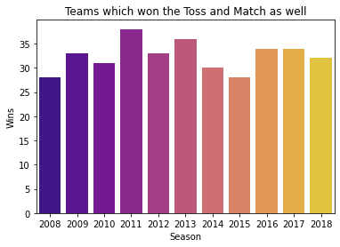

```python
sn.barplot(data=temp,x = 'Season',y = 'Wins',palette='plasma')
plt.title('Teams which won the Toss and Match as well')
plt.xlabel('Season')
plt.ylabel('Wins')
```

```python
px.bar(data_frame=temp,x = 'Season',y = 'Wins',color = 'Wins',hover_name='Season',title='Toss Won Match Won :)')
```

[interactive chart not shown]

```python
df_2008.head()
```

|  | season | team1 | team2 | toss_winner | toss_decision | winner | win_by_runs | win_by_wickets | player_of_match | venue |
| --- | --- | --- | --- | --- | --- | --- | --- | --- | --- | --- |
| 0 | 2008 | Chennai Super Kings | Rajasthan Royals | Rajasthan Royals | field | Rajasthan Royals | 0 | 3 | YK Pathan | Dr DY Patil Sports Academy |
| 1 | 2008 | Chennai Super Kings | Rajasthan Royals | Chennai Super Kings | bat | Rajasthan Royals | 0 | 8 | Sohail Tanvir | Sawai Mansingh Stadium |
| 2 | 2008 | Mumbai Indians | Delhi Daredevils | Delhi Daredevils | field | Mumbai Indians | 29 | 0 | SM Pollock | Dr DY Patil Sports Academy |
| 3 | 2008 | Kings XI Punjab | Kolkata Knight Riders | Kings XI Punjab | bat | Kings XI Punjab | 9 | 0 | IK Pathan | Punjab Cricket Association Stadium, Mohali |
| 4 | 2008 | Deccan Chargers | Royal Challengers Bangalore | Deccan Chargers | bat | Royal Challengers Bangalore | 0 | 5 | R Vinay Kumar | Rajiv Gandhi International Stadium, Uppal |

```python
def returndict(df):
    values = df['winner'].values
    values = list(values)
    df_val = dict(zip(values,map(values.count,values)))
    key_list = []
    val_list = []
    for key,val in df_val.items():
        key_list.append(key)
        val_list.append(val)
    df = pd.DataFrame()
    df['Team'] = key_list
    df['Wins'] = val_list
    return df

win_2008 = returndict(df_2008)
win_2009 = returndict(df_2009)
win_2010 = returndict(df_2010)
win_2011 = returndict(df_2011)
win_2012 = returndict(df_2012)
win_2013 = returndict(df_2013)
win_2014 = returndict(df_2014)
win_2015 = returndict(df_2015)
win_2016 = returndict(df_2016)
win_2017 = returndict(df_2017)
win_2018 = returndict(df_2018)
```

```python
fig = make_subplots(rows=4,cols=3,subplot_titles=("Successful Teams of Season 2008",
                                                 "Successful Teams of Season 2009",
                                                 "Successful Teams of Season 2010",
                                                 "Successful Teams of Season 2011",
                                                 "Successful Teams of Season 2012",
                                                 "Successful Teams of Season 2013",
                                                 "Successful Teams of Season 2014",
                                                 "Successful Teams of Season 2015",
                                                 "Successful Teams of Season 2016",
                                                 "Successful Teams of Season 2017",
                                                 "Successful Teams of Season 2018"),shared_yaxes=True)

fig.add_trace(go.Bar(x = win_2008['Team'],y = win_2008['Wins'],marker = dict(color = win_2008['Wins'],coloraxis = "coloraxis")),row = 1,col = 1)
fig.add_trace(go.Bar(x = win_2009['Team'],y = win_2009['Wins'],marker = dict(color = win_2009['Wins'],coloraxis = "coloraxis")),row = 1,col = 2)
fig.add_trace(go.Bar(x = win_2010['Team'],y = win_2010['Wins'],marker = dict(color = win_2010['Wins'],coloraxis = "coloraxis")),row = 1,col = 3)
fig.add_trace(go.Bar(x = win_2011['Team'],y = win_2011['Wins'],marker = dict(color = win_2011['Wins'],coloraxis = "coloraxis")),row = 2,col = 1)
fig.add_trace(go.Bar(x = win_2012['Team'],y = win_2012['Wins'],marker = dict(color = win_2012['Wins'],coloraxis = "coloraxis")),row = 2,col = 2)
fig.add_trace(go.Bar(x = win_2013['Team'],y = win_2013['Wins'],marker = dict(color = win_2013['Wins'],coloraxis = "coloraxis")),row = 2,col = 3)
fig.add_trace(go.Bar(x = win_2014['Team'],y = win_2014['Wins'],marker = dict(color = win_2014['Wins'],coloraxis = "coloraxis")),row = 3,col = 1)
fig.add_trace(go.Bar(x = win_2015['Team'],y = win_2015['Wins'],marker = dict(color = win_2015['Wins'],coloraxis = "coloraxis")),row = 3,col = 2)
fig.add_trace(go.Bar(x = win_2016['Team'],y = win_2016['Wins'],marker = dict(color = win_2016['Wins'],coloraxis = "coloraxis")),row = 3,col = 3)
fig.add_trace(go.Bar(x = win_2017['Team'],y = win_2017['Wins'],marker = dict(color = win_2017['Wins'],coloraxis = "coloraxis")),row = 4,col = 1)
fig.add_trace(go.Bar(x = win_2018['Team'],y = win_2018['Wins'],marker = dict(color = win_2018['Wins'],coloraxis = "coloraxis")),row = 4,col = 2)
fig.update_layout(height =1500,width = 1400,title_text = "Successful Teams in IPL from season 2008-2018")
fig.show()
```

[interactive chart not shown]

```python
win_2008_3 = win_2008.sort_values('Wins',ascending=False).head(3)
win_2009_3 = win_2009.sort_values('Wins',ascending=False).head(3)
win_2010_3 = win_2010.sort_values('Wins',ascending=False).head(3)
win_2011_3 = win_2011.sort_values('Wins',ascending=False).head(3)
win_2012_3 = win_2012.sort_values('Wins',ascending=False).head(3)
win_2013_3 = win_2013.sort_values('Wins',ascending=False).head(3)
win_2014_3 = win_2014.sort_values('Wins',ascending=False).head(3)
win_2015_3 = win_2015.sort_values('Wins',ascending=False).head(3)
win_2016_3 = win_2016.sort_values('Wins',ascending=False).head(3)
win_2017_3 = win_2017.sort_values('Wins',ascending=False).head(3)
win_2018_3 = win_2018.sort_values('Wins',ascending=False).head(3)
```

```python
fig = make_subplots(rows=6,cols=2,subplot_titles=("Successful Teams of Season 2008",
                                                 "Successful Teams of Season 2009",
                                                 "Successful Teams of Season 2010",
                                                 "Successful Teams of Season 2011",
                                                 "Successful Teams of Season 2012",
                                                 "Successful Teams of Season 2013",
                                                 "Successful Teams of Season 2014",
                                                 "Successful Teams of Season 2015",
                                                 "Successful Teams of Season 2016",
                                                 "Successful Teams of Season 2017",
                                                 "Successful Teams of Season 2018"),shared_yaxes=True)

fig.add_trace(go.Bar(x = win_2008_3['Team'],y = win_2008_3['Wins'],marker = dict(color = win_2008_3['Wins'],coloraxis = "coloraxis")),row = 1,col = 1)
fig.add_trace(go.Bar(x = win_2009_3['Team'],y = win_2009_3['Wins'],marker = dict(color = win_2009_3['Wins'],coloraxis = "coloraxis")),row = 1,col = 2)
fig.add_trace(go.Bar(x = win_2010_3['Team'],y = win_2010_3['Wins'],marker = dict(color = win_2010_3['Wins'],coloraxis = "coloraxis")),row = 2,col = 1)
fig.add_trace(go.Bar(x = win_2011_3['Team'],y = win_2011_3['Wins'],marker = dict(color = win_2011_3['Wins'],coloraxis = "coloraxis")),row = 2,col = 2)
fig.add_trace(go.Bar(x = win_2012_3['Team'],y = win_2012_3['Wins'],marker = dict(color = win_2012_3['Wins'],coloraxis = "coloraxis")),row = 3,col = 1)
fig.add_trace(go.Bar(x = win_2013_3['Team'],y = win_2013_3['Wins'],marker = dict(color = win_2013_3['Wins'],coloraxis = "coloraxis")),row = 3,col = 2)
fig.add_trace(go.Bar(x = win_2014_3['Team'],y = win_2014_3['Wins'],marker = dict(color = win_2014_3['Wins'],coloraxis = "coloraxis")),row = 4,col = 1)
fig.add_trace(go.Bar(x = win_2015_3['Team'],y = win_2015_3['Wins'],marker = dict(color = win_2015_3['Wins'],coloraxis = "coloraxis")),row = 4,col = 2)
fig.add_trace(go.Bar(x = win_2016_3['Team'],y = win_2016_3['Wins'],marker = dict(color = win_2016_3['Wins'],coloraxis = "coloraxis")),row = 5,col = 1)
fig.add_trace(go.Bar(x = win_2017_3['Team'],y = win_2017_3['Wins'],marker = dict(color = win_2017_3['Wins'],coloraxis = "coloraxis")),row = 5,col = 2)
fig.add_trace(go.Bar(x = win_2018_3['Team'],y = win_2018_3['Wins'],marker = dict(color = win_2018_3['Wins'],coloraxis = "coloraxis")),row = 6,col = 1)
fig.update_layout(height =1500,width = 900,title_text = "Successful Teams in IPL from season 2008-2018")
fig.show()
```

[interactive chart not shown]

**For the season `2008`,`Rajasthan Royals,Kings XI Punjab,Chennai SuperKings`,were the top 3 Performing Teams**

**For the season `2009`,`Delhi DareDevils,Deccan Chargers,Royal Challengers Banglore`,were the top 3 Performing Teams**

**For the season `2010`,`Mumbai Indians,Chennai SuperKings,Royal Challengers Banglore`,were the top 3 Performing Teams**

**For the season `2011`,`Mumbai Indians,Chennai SuperKings,Royal Challengers Banglore`,were the top 3 Performing Teams**

**For the season `2012`,`Kolkata Knight Riders,Delhi DareDevils,Mumbai Indians`,were the top 3 Performing Teams**

**For the season `2013`,`Mumbai Indians,Chennai SuperKings,Rajasthan Royals`,were the top 3 Performing Teams**

**For the season `2014`,`Kings XI Punjab,Kolkata Knight Riders,Chennai SuperKings`,were the top 3 Performing Teams**

**For the season `2015`,`Chennai Super Kings,Mumbai Indians,Royal Challengers Banglore`,were the top 3 Performing Teams**

**For the season `2016`,`Surises Hyderabad,Gujarat Lions,Royal Challengers Banglore`,were the top 3 Performing Teams**

**For the season `2017`,`Mumbai Indians,Rising Pune Supergaints,Kolkata Knight Riders`,were the top 3 Performing Teams**

**For the season `2018`,`Chennai SuperKings,Sunrises Hyderabad,Kolkata Knight Riders`,were the top 3 Performing Teams**

We can observe the trend from the following Graph,we can observe that Mumbai Indians,Chennai Super Kings,Royal Challengers Banglore,Kolkata Knight Riders were the most Performing Teams/Successful Teams out of all teams,as these teams were in the top-3 positions in the Points Table,hence these teams have participated most number of times in the World Champions T20 League from India,So these teams can be a selection choice if a company wants to endorse its products!,as these are the most loved teams in the Indian Premier League almost for all seasons

## Top Performing Batsmans

```python
deliveries.head()
```

|  | match_id | inning | batting_team | bowling_team | over | ball | batsman | non_striker | bowler | is_super_over | wide_runs | bye_runs | legbye_runs | noball_runs | penalty_runs | batsman_runs | extra_runs | total_runs | player_dismissed | dismissal_kind | fielder |
| --- | --- | --- | --- | --- | --- | --- | --- | --- | --- | --- | --- | --- | --- | --- | --- | --- | --- | --- | --- | --- | --- |
| 0 | 1 | 1 | Sunrisers Hyderabad | Royal Challengers Bangalore | 1 | 1 | DA Warner | S Dhawan | TS Mills | 0 | 0 | 0 | 0 | 0 | 0 | 0 | 0 | 0 | NaN | NaN | NaN |
| 1 | 1 | 1 | Sunrisers Hyderabad | Royal Challengers Bangalore | 1 | 2 | DA Warner | S Dhawan | TS Mills | 0 | 0 | 0 | 0 | 0 | 0 | 0 | 0 | 0 | NaN | NaN | NaN |
| 2 | 1 | 1 | Sunrisers Hyderabad | Royal Challengers Bangalore | 1 | 3 | DA Warner | S Dhawan | TS Mills | 0 | 0 | 0 | 0 | 0 | 0 | 4 | 0 | 4 | NaN | NaN | NaN |
| 3 | 1 | 1 | Sunrisers Hyderabad | Royal Challengers Bangalore | 1 | 4 | DA Warner | S Dhawan | TS Mills | 0 | 0 | 0 | 0 | 0 | 0 | 0 | 0 | 0 | NaN | NaN | NaN |
| 4 | 1 | 1 | Sunrisers Hyderabad | Royal Challengers Bangalore | 1 | 5 | DA Warner | S Dhawan | TS Mills | 0 | 2 | 0 | 0 | 0 | 0 | 0 | 2 | 2 | NaN | NaN | NaN |

```python
a = list(deliveries['batting_team'].unique())
a
```

```
['Sunrisers Hyderabad',
 'Royal Challengers Bangalore',
 'Mumbai Indians',
 'Rising Pune Supergiant',
 'Gujarat Lions',
 'Kolkata Knight Riders',
 'Kings XI Punjab',
 'Delhi Daredevils',
 'Chennai Super Kings',
 'Rajasthan Royals',
 'Deccan Chargers',
 'Kochi Tuskers Kerala',
 'Pune Warriors',
 'Rising Pune Supergiants',
 'Delhi Capitals']
```

```python
df_csk = deliveries[(deliveries['batting_team']=='Chennai Super Kings')&(deliveries['total_runs']!=0)&(deliveries['total_runs']!=5)&(deliveries['total_runs']!=7)]
df_mi = deliveries[(deliveries['batting_team']=='Mumbai Indians')&(deliveries['total_runs']!=0)&(deliveries['total_runs']!=5)&(deliveries['total_runs']!=7)]
df_rcb = deliveries[(deliveries['batting_team']=='Royal Challengers Bangalore')&(deliveries['total_runs']!=0)&(deliveries['total_runs']!=5)&(deliveries['total_runs']!=7)]
df_kkr = deliveries[(deliveries['batting_team']=='Kolkata Knight Riders')&(deliveries['total_runs']!=0)&(deliveries['total_runs']!=5)&(deliveries['total_runs']!=7)]
df_rr = deliveries[(deliveries['batting_team']=='Rajasthan Royals')&(deliveries['total_runs']!=0)&(deliveries['total_runs']!=5)&(deliveries['total_runs']!=7)]
df_kxip = deliveries[(deliveries['batting_team']=='Kings XI Punjab')&(deliveries['total_runs']!=0)&(deliveries['total_runs']!=5)&(deliveries['total_runs']!=7)]
df_dd = deliveries[(deliveries['batting_team']=='Delhi Daredevils') | (deliveries['batting_team']=='Delhi Capitals')&(deliveries['total_runs']!=0)&(deliveries['total_runs']!=5)&(deliveries['total_runs']!=7)]
df_srh = deliveries[(deliveries['batting_team']=='Sunrisers Hyderabad')|(deliveries['batting_team']=='Deccan Chargers')&(deliveries['total_runs']!=0)&(deliveries['total_runs']!=5)&(deliveries['total_runs']!=7)]
```

```python
df_csk.head()
```

|  | match_id | inning | batting_team | bowling_team | over | ball | batsman | non_striker | bowler | is_super_over | wide_runs | bye_runs | legbye_runs | noball_runs | penalty_runs | batsman_runs | extra_runs | total_runs | player_dismissed | dismissal_kind | fielder |
| --- | --- | --- | --- | --- | --- | --- | --- | --- | --- | --- | --- | --- | --- | --- | --- | --- | --- | --- | --- | --- | --- |
| 14089 | 61 | 1 | Chennai Super Kings | Kings XI Punjab | 1 | 3 | PA Patel | ML Hayden | B Lee | 0 | 0 | 0 | 0 | 0 | 0 | 1 | 0 | 1 | NaN | NaN | NaN |
| 14091 | 61 | 1 | Chennai Super Kings | Kings XI Punjab | 1 | 5 | ML Hayden | PA Patel | B Lee | 0 | 0 | 0 | 0 | 0 | 0 | 4 | 0 | 4 | NaN | NaN | NaN |
| 14093 | 61 | 1 | Chennai Super Kings | Kings XI Punjab | 2 | 1 | PA Patel | ML Hayden | S Sreesanth | 0 | 0 | 0 | 0 | 0 | 0 | 4 | 0 | 4 | NaN | NaN | NaN |
| 14094 | 61 | 1 | Chennai Super Kings | Kings XI Punjab | 2 | 2 | PA Patel | ML Hayden | S Sreesanth | 0 | 0 | 0 | 0 | 0 | 0 | 4 | 0 | 4 | NaN | NaN | NaN |
| 14095 | 61 | 1 | Chennai Super Kings | Kings XI Punjab | 2 | 3 | PA Patel | ML Hayden | S Sreesanth | 0 | 0 | 0 | 0 | 0 | 0 | 4 | 0 | 4 | NaN | NaN | NaN |

```python
csk_bat = list(df_csk['batsman'].unique())
mi_bat = list(df_mi['batsman'].unique())
rcb_bat = list(df_rcb['batsman'].unique())
kkr_bat = list(df_kkr['batsman'].unique())
rr_bat = list(df_rr['batsman'].unique())
kxip_bat = list(df_kxip['batsman'].unique())
dd_bat = list(df_dd['batsman'].unique())
srh_bat = list(df_srh['batsman'].unique())
```

```python
def getmap(df,player):
    temp = df.groupby(df['batsman']==player)[['total_runs']].sum()
    runs = temp['total_runs'][1]
    return runs
```

```python
df_list = [df_csk,df_mi,df_rcb,df_kkr,df_rr,df_kxip,df_dd,df_srh]
bat_list = [csk_bat,mi_bat,rcb_bat,kkr_bat,rr_bat,kxip_bat,dd_bat,srh_bat]
teams = ['csk','mi','rcb','kkr','rr','kxip','dd','srh']
year = [i for i in range(2008,2019)]
count = 2008
main_map = {}
for team,batsman,team_name in zip(df_list,bat_list,teams):
    mapper = {}
    for player in batsman:
        mapper[player] = getmap(team,player)

    main_map[team_name] = mapper
    count+=1
```

```python
def gettopbatdf(team):
    temp = main_map[team]
    temp = dict(sorted(temp.items(),key=lambda x:x[1],reverse=True))
    temp = dict(list(temp.items())[:10])
    top_bat_df = pd.DataFrame()
    name = []
    runs = []
    for key,val in temp.items():
        name.append(key)
        runs.append(val)
    top_bat_df['Player'] = name
    top_bat_df['Runs'] = runs

    return top_bat_df
```

```python
teams = ['csk','mi','rcb','kkr','rr','kxip','dd','srh']
```

```python
top_bat_csk = gettopbatdf('csk')
top_bat_mi  = gettopbatdf('mi')
top_bat_rcb = gettopbatdf('rcb')
top_bat_kkr = gettopbatdf('kkr')
top_bat_rr = gettopbatdf('rr')
top_bat_kxip = gettopbatdf('kxip')
top_bat_dd = gettopbatdf('dd')
top_bat_srh = gettopbatdf('srh')
```

```python
top_bat_csk
```

|  | Player | Runs |
| --- | --- | --- |
| 0 | SK Raina | 4747 |
| 1 | MS Dhoni | 4081 |
| 2 | MEK Hussey | 1838 |
| 3 | M Vijay | 1730 |
| 4 | F du Plessis | 1702 |
| 5 | S Badrinath | 1515 |
| 6 | ML Hayden | 1175 |
| 7 | DR Smith | 1020 |
| 8 | SR Watson | 1013 |
| 9 | DJ Bravo | 990 |

```python
teams = ['csk','mi','rcb','kkr','rr','kxip','dd','srh']

fig = make_subplots(rows=4,cols=2,subplot_titles=('CSK','MI','RCB','KKR',
                                                 'RR','KXIP','DD','SRH'),start_cell = 'top-left',
                                  specs=[[{'type':'polar'},{'type':'polar'}],
                                         [{'type':'polar'},{'type':'polar'}],
                                         [{'type':'polar'},{'type':'polar'}],
                                         [{'type':'polar'},{'type':'polar'}]],shared_yaxes=True)

# fig = make_subplots(rows=4,cols=2,specs=[[{'type':'polar'},{'type':'polar'}],
#                                          [{'type':'polar'},{'type':'polar'}],
#                                          [{'type':'polar'},{'type':'polar'}],
#                                          [{'type':'polar'},{'type':'polar'}]])

fig.add_trace(go.Barpolar(theta=list(top_bat_csk['Player'].unique()),r = list(top_bat_csk['Runs'].unique())),1,1)

fig.add_trace(go.Barpolar(theta=list(top_bat_mi['Player'].unique()),r = list(top_bat_mi['Runs'].unique())),1,2)

fig.add_trace(go.Barpolar(theta=list(top_bat_rcb['Player'].unique()),r = list(top_bat_rcb['Runs'].unique())),2,1)

fig.add_trace(go.Barpolar(theta=list(top_bat_kkr['Player'].unique()),r = list(top_bat_kkr['Runs'].unique())),2,2)

fig.add_trace(go.Barpolar(theta=list(top_bat_rr['Player'].unique()),r = list(top_bat_rr['Runs'].unique())),3,1)

fig.add_trace(go.Barpolar(theta=list(top_bat_kxip['Player'].unique()),r = list(top_bat_kxip['Runs'].unique())),3,2)

fig.add_trace(go.Barpolar(theta=list(top_bat_dd['Player'].unique()),r = list(top_bat_dd['Runs'].unique())),4,1)

fig.add_trace(go.Barpolar(theta=list(top_bat_srh['Player'].unique()),r = list(top_bat_srh['Runs'].unique())),4,2)


# fig.update_traces(hoverinfo="label+percent+name")

# fig.update_layout(
#     title_text="Global Emissions 1990-2011",
#     # Add annotations in the center of the donut pies.
#     annotations=[dict(text='GHG', x=0.18, y=0.5, font_size=20, showarrow=False),
#                  dict(text='CO2', x=0.82, y=0.5, font_size=20, showarrow=False),
#                 dict(text='CO2', x=0.82, y=0.5, font_size=20, showarrow=False),
#                 dict(text='CO2', x=0.82, y=0.5, font_size=20, showarrow=False),
#                 dict(text='CO2', x=0.82, y=0.5, font_size=20, showarrow=False),
#                 dict(text='CO2', x=0.82, y=0.5, font_size=20, showarrow=False),
#                 dict(text='CO2', x=0.82, y=0.5, font_size=20, showarrow=False),
#                 dict(text='CO2', x=0.82, y=0.5, font_size=20, showarrow=False)])

fig.update_layout(height =1600,width = 1000,title_text = "Top Performing Batsmans From Each team")
# annot =list(fig.layout.annotations)
# fig.layout.annotations = annot
fig.show()
```

[interactive chart not shown]

## Top 5 Batsmans Stats

```python
def gettopbatdf(team):
    temp = main_map[team]
    temp = dict(sorted(temp.items(),key=lambda x:x[1],reverse=True))
    temp = dict(list(temp.items())[:5])
    keys = []
    for key,val in temp.items():
        keys.append(key)

    return keys
```

```python
bat_csk = gettopbatdf('csk')
bat_mi  = gettopbatdf('mi')
bat_rcb = gettopbatdf('rcb')
bat_kkr = gettopbatdf('kkr')
bat_rr = gettopbatdf('rr')
bat_kxip = gettopbatdf('kxip')
bat_dd = gettopbatdf('dd')
bat_srh = gettopbatdf('srh')
```

```python
bat_csk
```

```
['SK Raina', 'MS Dhoni', 'MEK Hussey', 'M Vijay', 'F du Plessis']
```

```python
def getruns(df,player):
    temp = df[(df['batsman']==player)]
    runs = list(temp['total_runs'])
    mapper = dict(zip(runs,map(runs.count,runs)))
    return mapper
```

```python
df_list = [df_csk,df_mi,df_rcb,df_kkr,df_rr,df_kxip,df_dd,df_srh]
bats = [bat_csk,bat_mi,bat_rcb,bat_kkr,bat_rr,bat_kxip,bat_dd,bat_srh]
teams = ['csk','mi','rcb','kkr','rr','kxip','dd','srh']
final_mapper = {}
for i,j,k in zip(df_list,bats,teams):
    mapper = {}
    for player in j:
        mapper[player] = getruns(i,player)
        final_mapper[k] = mapper
```

```python
def gettop5dataframe(team):
    top_5 = dict(list(final_mapper[team].items()))
    dummy = pd.DataFrame(top_5)
    dummy = dummy.T
    dummy = dummy.fillna(value = 0)
    for i in dummy.columns:
        if i==5 or i==8 or i==10 or i==7:
            dummy = dummy.drop([i],axis = 1)

    dummy = dummy.astype('int32')
    dummy['Player'] = dummy.index
    dummy = dummy.reset_index()
    dummy = dummy[['Player',1,2,3,4,6]]
    return dummy
```

```python
teams = ['csk','mi','rcb','kkr','rr','kxip','dd','srh']
```

```python
csk_ind = gettop5dataframe('csk')
mi_ind = gettop5dataframe('mi')
rcb_ind = gettop5dataframe('rcb')
kkr_ind = gettop5dataframe('kkr')
rr_ind = gettop5dataframe('rr')
kxip_ind = gettop5dataframe('kxip')
dd_ind = gettop5dataframe('dd')
srh_ind = gettop5dataframe('srh')
```

```python
csk_ind
```

|  | Player | 1 | 2 | 3 | 4 | 6 |
| --- | --- | --- | --- | --- | --- | --- |
| 0 | SK Raina | 1497 | 259 | 14 | 412 | 171 |
| 1 | MS Dhoni | 1254 | 314 | 15 | 269 | 177 |
| 2 | MEK Hussey | 634 | 89 | 8 | 183 | 45 |
| 3 | M Vijay | 467 | 117 | 11 | 147 | 68 |
| 4 | F du Plessis | 590 | 90 | 10 | 146 | 50 |

```python
def getnameandruns(df_i):
    final = []
    for i in range(df_i.shape[0]):
        first = df_i.iloc[[i]]
        temp = []
        for i in first.columns:
            a = []
            a.append(list(first[i]))
            a = sum(a,[])
            temp.append(a)

        final.append(temp)


    final = sum(final,[])
    final = sum(final,[])
    name = [i for i in final if type(i)!=int]
    runs = [i for i in final if type(i)==int]
    final_runs = []
    start = 0
    end = 5
    while end<=len(runs):
        temp = runs[start:end]
        final_runs.append(temp)
        start = end
        end+=5

    return name,final_runs
```

```python
teams = ['csk','mi','rcb','kkr','rr','kxip','dd','srh']
```

```python
csk_name,csk_runs = getnameandruns(csk_ind)
mi_name,mi_runs = getnameandruns(mi_ind)
rcb_name,rcb_runs = getnameandruns(rcb_ind)
kkr_name,kkr_runs = getnameandruns(kkr_ind)
rr_name,rr_runs = getnameandruns(rr_ind)
kxip_name,kxip_runs = getnameandruns(kxip_ind)
dd_name,dd_runs = getnameandruns(dd_ind)
srh_name,srh_runs = getnameandruns(srh_ind)
```

```python
srh_runs
```

```
[[1186, 173, 17, 404, 73],
 [910, 235, 10, 313, 122],
 [443, 91, 4, 114, 44],
 [277, 34, 2, 135, 64],
 [396, 62, 1, 94, 51]]
```

```python
list(top_bat_csk['Runs'].unique())[:5]
```

```
[4747, 4081, 1838, 1730, 1702]
```

```python
names = [csk_name,mi_name,rcb_name,kkr_name,rcb_name,kxip_name,dd_name,srh_name]
final = []
for i in range(len(names)):
    final.append(names[i])

final
```

```
[['SK Raina', 'MS Dhoni', 'MEK Hussey', 'M Vijay', 'F du Plessis'],
 ['RG Sharma', 'KA Pollard', 'AT Rayudu', 'SR Tendulkar', 'HH Pandya'],
 ['V Kohli', 'AB de Villiers', 'CH Gayle', 'JH Kallis', 'R Dravid'],
 ['G Gambhir', 'RV Uthappa', 'YK Pathan', 'AD Russell', 'CA Lynn'],
 ['V Kohli', 'AB de Villiers', 'CH Gayle', 'JH Kallis', 'R Dravid'],
 ['SE Marsh', 'DA Miller', 'KL Rahul', 'GJ Maxwell', 'WP Saha'],
 ['V Sehwag', 'RR Pant', 'SS Iyer', 'DA Warner', 'G Gambhir'],
 ['S Dhawan', 'DA Warner', 'KS Williamson', 'AC Gilchrist', 'RG Sharma']]
```

```python
def drawplots(player_runs,player_names,player_name,top_bat,text):
    runs = [1,2,3,4,6]
    runs = [str(i) for i in runs]
    fig = make_subplots(rows=2,cols = 3,subplot_titles=tuple(player_names),
                       specs=[[{'type':'domain'},{'type':'domain'},{'type':'domain'}],
                              [{'type':'domain'},{'type':'domain'},{'type':'domain'}]],shared_yaxes=True)
    fig.add_trace(go.Pie(labels=runs,values=player_runs[0],name = player_names[0]),1,1)
    fig.add_trace(go.Pie(labels=runs,values=player_runs[1],name = player_names[1]),1,2)
    fig.add_trace(go.Pie(labels=runs,values=player_runs[2],name = player_names[2]),1,3)
    fig.add_trace(go.Pie(labels=runs,values=player_runs[3],name = player_names[3]),2,1)
    fig.add_trace(go.Pie(labels=runs,values=player_runs[4],name = player_names[4]),2,2)
    fig.add_trace(go.Pie(labels = player_name,values=list(top_bat['Runs'].unique())[:5]),2,3)
    fig.update_traces(hole=.4, hoverinfo="label+percent+name")
    fig.update_layout(height = 750,width = 900,title_text = text)

    fig.show()
```

```python
teams = ['csk','mi','rcb','kkr','rr','kxip','dd','srh']
top_bat = [top_bat_csk,top_bat_mi,top_bat_rcb,top_bat_kkr,top_bat_rr,top_bat_kxip,top_bat_dd,top_bat_srh]
player_name = [csk_name,mi_name,rcb_name,kkr_name,rr_name,kxip_name,dd_name,srh_name]
player_runs = [csk_runs,mi_runs,rcb_runs,kkr_runs,rr_runs,kxip_runs,dd_runs,srh_runs]
for i,j,k,l,m in zip(range(len(teams)),range(len(player_name)),range(len(player_runs)),range(len(top_bat)),range(len(final))):

    drawplots(player_runs[k],player_name[j],final[m],top_bat[l],text = "Top 5 Batsmans From"+" "+str(teams[i]).upper())
    print("-"*120)
```

[interactive chart not shown]

[interactive chart not shown]

[interactive chart not shown]

[interactive chart not shown]

[interactive chart not shown]

[interactive chart not shown]

[interactive chart not shown]

[interactive chart not shown]

## Observation

From Chennai Super Kings,Suresh Raina,MS Dhoni,MK Hussey have very good Figures

```python
def getresults(df,player_list):

    final = {}
    for player in player_list:
        temp = df[(df['batsman']==player)]
        bowler = list(temp['bowler'])
        bowler_map = dict(Counter(bowler))
        bowler_map = dict(sorted(bowler_map.items(),key=lambda x:x[1],reverse=True))
        bowler_map = dict(list(bowler_map.items())[:5])
        final[player] = bowler_map

    final_name = []
    final_runs = []
    for key,val in final.items():
        player_runs = []
        player_name = []
        for key1,val1 in val.items():
            player_name.append(key1)
            player_runs.append(val1)

        final_name.append(player_name)
        final_runs.append(player_runs)


    return final_name,final_runs
```

```python
teams = ['csk','mi','rcb','kkr','rr','kxip','dd','srh']
```

```python
csk_player,csk_run = getresults(df_csk,csk_name)
mi_player,mi_run = getresults(df_mi,mi_name)
rcb_player,rcb_run = getresults(df_rcb,rcb_name)
kkr_player,kkr_run = getresults(df_kkr,kkr_name)
rr_player,rr_run = getresults(df_rr,rr_name)
kxip_player,kxip_run = getresults(df_kxip,kxip_name)
dd_player,dd_run = getresults(df_dd,dd_name)
srh_player,srh_run = getresults(df_srh,srh_name)
```

```python
srh_player[0]
```

```
['Harbhajan Singh', 'DS Kulkarni', 'UT Yadav', 'MM Sharma', 'M Morkel']
```

```python
srh_run
```

```
[[81, 79, 68, 55, 55],
 [81, 71, 67, 62, 53],
 [51, 39, 36, 35, 32],
 [23, 18, 18, 17, 17],
 [30, 27, 23, 21, 17]]
```

```python
csk_player
```

```
[['Harbhajan Singh', 'PP Chawla', 'A Mishra', 'SK Trivedi', 'JH Kallis'],
 ['PP Ojha', 'SL Malinga', 'DW Steyn', 'KA Pollard', 'IK Pathan'],
 ['JH Kallis', 'R Bhatia', 'SK Trivedi', 'L Balaji', 'IK Pathan'],
 ['SL Malinga', 'RP Singh', 'UT Yadav', 'RJ Harris', 'YK Pathan'],
 ['Harbhajan Singh', 'A Mishra', 'PP Chawla', 'AR Patel', 'M Ashwin']]
```

```python
csk_run
```

```
[[75, 63, 54, 50, 44],
 [60, 44, 42, 42, 36],
 [31, 31, 27, 26, 25],
 [23, 22, 22, 20, 20],
 [33, 24, 23, 21, 19]]
```

```python
def drawplots(player_runs,player_names,batsman_name):


    fig = make_subplots(rows=2,cols = 3,subplot_titles=tuple(batsman_name),
                       specs=[[{'type':'domain'},{'type':'domain'},{'type':'domain'}],
                              [{'type':'domain'},{'type':'domain'},{'type':'domain'}]],shared_yaxes=True)
    fig.add_trace(go.Pie(labels=player_names[0],values=player_runs[0],name = batsman_name[0]),1,1)
    fig.add_trace(go.Pie(labels=player_names[1],values=player_runs[1],name = batsman_name[1]),1,2)
    fig.add_trace(go.Pie(labels=player_names[2],values=player_runs[2],name = batsman_name[2]),1,3)
    fig.add_trace(go.Pie(labels=player_names[3],values=player_runs[3],name = batsman_name[3]),2,1)
    fig.add_trace(go.Pie(labels=player_names[4],values=player_runs[4],name = batsman_name[4]),2,2)
#     fig.add_trace(go.Pie(labels=player_names[4],values=player_runs[4]),2,3)
    fig.update_traces(hole=.4, hoverinfo="label+percent+value")
    fig.update_layout(height = 750,width = 900)

    fig.show()
```

```python
teams = ['csk','mi','rcb','kkr','rr','kxip','dd','srh']
top_bat = [top_bat_csk,top_bat_mi,top_bat_rcb,top_bat_kkr,top_bat_rr,top_bat_kxip,top_bat_dd,top_bat_srh]
player_name = [csk_player,mi_player,rcb_player,kkr_player,rr_player,kxip_player,dd_player,srh_player]
player_runs = [csk_run,mi_run,rcb_run,kkr_run,rr_run,kxip_run,dd_run,srh_run]
batsman_name = [csk_name,mi_name,rcb_name,kkr_name,rr_name,kxip_name,dd_name,srh_name]
for j,k,l in zip(player_name,player_runs,batsman_name):
    drawplots(k,j,l)
    print("-"*120)
```

[interactive chart not shown]

[interactive chart not shown]

[interactive chart not shown]

[interactive chart not shown]

[interactive chart not shown]

[interactive chart not shown]

[interactive chart not shown]

[interactive chart not shown]